# MCDA_example

Andrea Schiavo

2025-02-17

# This is a tutorial to run a MCDA analysis on the output of the models from Seawise H2020 project case studies

# 1. MAUT analysis

## 1.1 Required libraries:

- library(jsonlite)
- library(dplyr)
- library(ggplot2)
- library(reshape2)
- library(GGally)
- library(RColorBrewer)

## 1.2 import the mcda script and set up the required lists to run the analysis

```r
source('mcda.R')

time_period <- c("2025-2030", "2035-2040", "2045-2050", "2055-2060")
scenarios <- c("Fmsy_RCP45", "Fmsy_RCP85", "PGY_RCP45", "PGY_RCP85", "SQ_RCP45", "SQ_RCP85")
criteria <- c("ssb", "f", "rbs", "mml", "apex_pred", "employment", "wage", "gva", "rsl", "co2")
sub_criteria <- c("all")
# sub_criteria <- list(ssb = c('DPS171819', 'HKE1718', 'MUT1718', 'NEP17', 'SOL17'),
#                      f = c('DPS171819', 'HKE1718', 'MUT1718', 'NEP17', 'SOL17'))
```

A sub_criteria list of lists can be passed to select a subset of the sub-criteria. See the commented-out lines of the code chunk above for reference.

## 1.3 initialize the MCDA object

```r
mcda <- Mcda(time_period = time_period,
             scenarios = scenarios,
             criteria = criteria,
             sub_criteria = "all",
             options_file = "data/MCDA_options.json")
```

## 1.4 load the input data and calculate the utitlities of the critaria based on the MCDA option file (at the bottom of the tutorial you can find the script needed to export the option file .json)

Utilities are calculated based on utility functions and reference points defined for each criteria into the options file (see 3.)

```r
mcda <- load_data(mcda)

mcda <- calculate_utilities(mcda, quantile = 0.5)
```

quantile = 0.5 it’s an additional argument (…). It is needed to add a filter to the input data and extract one single value of the criteria for each combination of time-period and management scenario (alternatives). Without this additional argument the function would filter only by time-period and scenario (default filter), returning a dataset with all 3 quantile levels and failing the calculation of the utilities. (At the moment it’s not possible to evaluate all the quantile levels on a single run) To explore the uncertainty of the data it is possible to run multiple analysis with different quantile levels (0.025, 0.5, 0.975) and then concatenate the dataframes (see 1.8 *generate_df* function)

## 1.5 It is always possible to modify the weights of the criteria/subcriteria included into the *mcda* object.

Weights are saved into a separate vector and can be modified with the function *set_weights*. The criteria whose weights need to be changed are passed as a list into the function, along with a corresponding list of new weights. Make sure the positions of criteria and weights are correct

```
## [1] "Weight of SSB before modification: 1.00"
```

```r
mcda <- set_weights(mcda, criteria = c('ssb', 'f'), new_weights = c(2, 1))
```

```
## [1] "Weight of SSB after modification: 2.00"
```

## 1.6 Once the *mcda* object is created and the utilities are calculated it is possible to aggregate the criteria.

two methods are implemented:

- *sum*: this method performs the sum of the utilities of the criteria passed. If *weighted* is set to TRUE, the output would be a weighted sum with normalized weights between 0-1.
- *gmean*: this method performs the geometric mean of the utilities of the criteria passed. If *weighted* is set to TRUE, the output would be a weighted geometric mean with normalized weights between 0-1.

If a criterion has sub-criteria, these can be aggregated by passing the *sub_criteria* argument as TRUE. If two criteria that share the same sub-criteria/criterion are passed with *sub_criteria* = TRUE, they will be combined into a new criterion retaining the same sub-criteria as the original ones.

One criterion can be passed with *sub_criteria* = FALSE to generate a new labeled criterion (see 1.7 Habitats aggregation).

*set_weight* argument is 1 by default. By changing the value of *set_weight* the weight of the new criterion is set accordingly (but it can be modified later with the function *set_weights*) (see 1.5)

```r
mcda <- aggregate_utilities(mcda,
                            criteria = c('f'),
                            label = "combined_f",
                            method = "sum",
                            set_weight = 1,
                            sub_criteria = TRUE,
                            weighted = TRUE)

mcda <- aggregate_utilities(mcda,
                            criteria = c('ssb'),
                            label = "combined_ssb",
                            method = "sum",
                            set_weight = 1,
                            sub_criteria = TRUE,
                            weighted = TRUE)
```

## 1.7 Aggregate the criteria into the macro-criteria from the Seawise online tool. Macro-criteria are then passed to the *run_maut* function.

This function runs the Multi-Attribute Utility Theory analysis performing a weighted sum on the passed criteria.

```r
# STOCKS
mcda <- aggregate_utilities(mcda, criteria = c('combined_f', 'combined_ssb'), label = "stocks", method = "sum", set_weight = 1, sub_criteria = FALSE, weighted = TRUE)
# BIODIVERSITY
mcda <- aggregate_utilities(mcda, criteria = c('mml', 'apex_pred'), label = "biodiversity", method = "sum", set_weight = 1, sub_criteria = FALSE, weighted = TRUE)
# HABITATS
mcda <- aggregate_utilities(mcda, criteria = c('rbs'), label = "habitats", method = "sum", set_weight = 1, sub_criteria = FALSE, weighted = TRUE)
# COMMUNITY
mcda <- aggregate_utilities(mcda, criteria = c('employment', 'rsl', 'wage'), label = "community", method = "sum", set_weight = 1, sub_criteria = FALSE, weighted = TRUE)
# REVENUE
mcda <- aggregate_utilities(mcda, criteria = c('gva'), label = "revenue", method = "sum", set_weight = 1, sub_criteria = FALSE, weighted = TRUE)
# WELL-BEING
mcda <- aggregate_utilities(mcda, criteria = c('co2'), label = "well-being", method = "sum", set_weight = 1, sub_criteria = FALSE, weighted = TRUE)


mcda  <- run_maut(mcda, criteria = c("stocks", "biodiversity","habitats", "community", "revenue", "well-being"))
```

## 1.8 Now, the total utility is calculated resulting from the combination of the passed macro-criteria, across all the scenarios and time-periods.

To visualize the outputs, a dataframe can be generated with the function *generate_df*. It is also possible to extract the utilities of the sub-criteria, by passing the list of criteria carrying those sub-criteria in the *sub_criteria* argument.

The function *top_scenarios* returns a dataframe with a selected number of scenarios (default *num* = 5), sorted by one selected criterion (*criterion* = “total_utility”, default), in ascending (*ascending* = TRUE) or descending (*ascending* = FALSE, default) order.

```r
# transfer the results on a df
df = generate_df(mcda,
                     criteria = c("combined_f", "combined_ssb", "rbs", "mml", "apex_pred", "employment", "wage", "gva", "rsl", "co2",
                                  "stocks", "biodiversity","habitats", "community", "revenue", "well-being"),
                     sub_criteria = c('ssb', 'f'))


# select top or bottom scenarios based on 1 criterion
tops = top_scenarios(dataframe = df,
                     criterion = 'total_utility',
                     num = 5,
                     ascending = FALSE)
```

To evaluate the uncertainty of the model’s outputs it’s possible to run again the maut analysis from 1.4 on, changing the quantile level into the *calculate_utilities* function (e.g.: *calculate_utilities(mcda, quantile = 0.025)* )

# 2 VISUALIZATION

## 2.1 3 types of graphs can be generate with this library using the dataframe output from the MCDA analysis:

### 2.1.1 Stacked bar chart (*plot_histogram*):

This function generates a stacked bar chart. On the x axis the scenarios, on the y axis the utility values for the criteria of the MCDA. *weights* argument is always needed; *parents* argument is needed in case *subcriteria* is set to TRUE; *scenarios* (default, = NULL) can be passed as a list of scenarios to compare fewer alternatives. If NULL or blank, all the scenarios included in the MCDA are plotted; *subcriteria* (default FALSE) can be set to TRUE to plot the sub-criteria of the criteria passed; *color* (default, = “Set3”) can be modified with a discrete color palette from **RColorBrewer**;

v.0 notes: when plotting macro-criteria and setting *subcriteria* as TRUE, the legend for the macro-criteria is not visualized

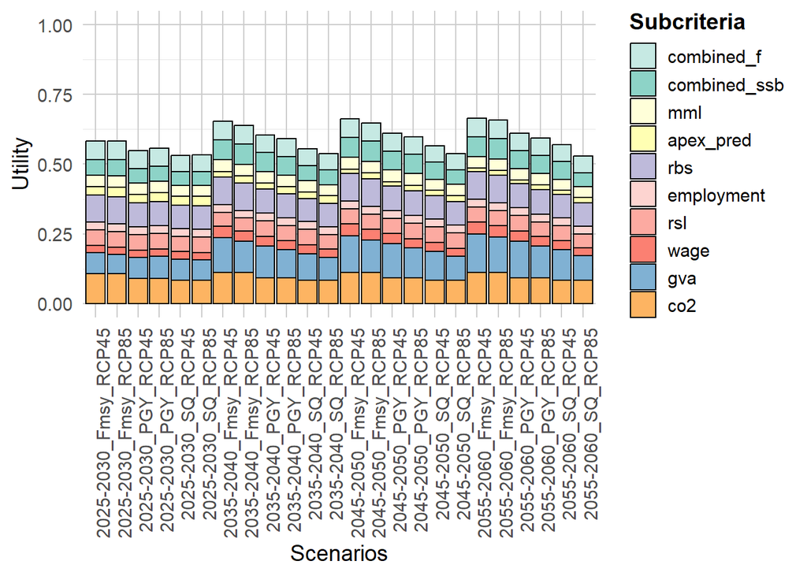

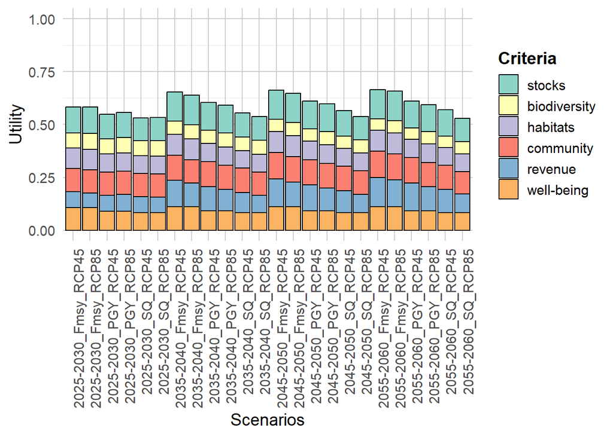

```r
plot_histogram(df,
               criteria = c("stocks", "biodiversity","habitats", "community", "revenue", "well-being"),
               weights = mcda$weights,
               parents = mcda$parents,
               scenarios = NULL,
               subcriteria = TRUE,
               color = "Set3"
               )
plot_histogram(df,
               criteria = c("stocks", "biodiversity","habitats", "community", "revenue", "well-being"),
               weights = mcda$weights,
               parents = mcda$parents,
               scenarios = NULL,
               subcriteria = FALSE,
               color = "Set3"
               )
```

### 2.1.2 Utility matrix visualization (*plot_matrix*)

This function generates matrix plot. On the x axis the criteria, on the y axis the scenarios, while the color gradient represent the utility values. *criteria* (default, = “all”) is the list of criteria to plot; *scenarios* (default, = “all”) is the list of scenarios to plot; *color* (default, = “Set3”) can be modified with a discrete color palette from **RColorBrewer**; *style* (default, = “minimal”) set the style of the plot

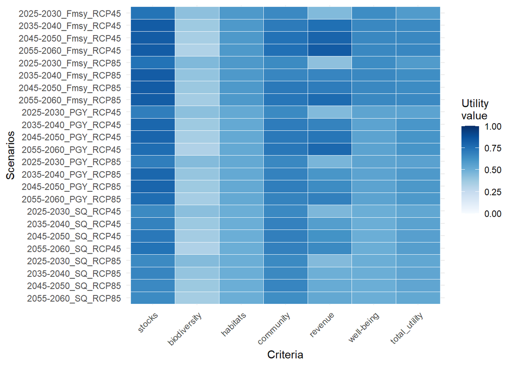

```r
plot_matrix(df, criteria = c("stocks", "biodiversity","habitats", "community", "revenue", "well-being", "total_utility"),
            color = "Blues")
```

### 2.1.3 Parallel plot (*plot_parallel_graph*)

This function generates a parallel plot. On the x axis the criteria, on the y axis the utilities; the plots connecting the criteria axes are the utilities of the different scenarios.

*criteria* is the list of criteria to plot; *highlight* (default, = “top”) is the criterion for selecting the highlighted scenarios; *top_bottom_criterion* (default, = “total_utility”) the criterion for sorting of the top scenarios (this function uses the *top_scenario* function);

v.0 note: only top 5 scenarios sorted by “total_utility” can be highlighted in this version. the idea is to having the possibility to pass a list of scenarios into *highlight* to highlight those in the chart

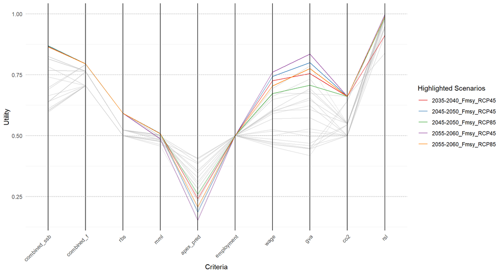

```r
plot_parallel_graph(df, criteria = c('combined_ssb', 'combined_f', 'rbs', 'mml', 'apex_pred', 'employment', 'wage', 'gva','co2', 'rsl'), #
                    highlight = "top",
                    top_bottom_criterion = "total_utility")
```

# 3. OPTION FILE GENERATION

The **mcda.R** script uses an option file in .json format to pick the information on the criteria needed into the analysis (sub-criteria, weights, utility functions, reference points and input data path).

**export_json.R** generates this type of file and can be edited as desired as long as the same criteria names are used into the **mcda.R** script and found as columns in the input .csv files

The reference points follow these criteria: - ssb: c(Blim, Bmsy, U_Blim, U_Bmsy) U_Blim is set to 0.1, U_Bmsy is set to 0.99 In case of stocks for which biomass indicators are not available the reference points are: c(1/2 Bcurrent, Bcurrent, U_1/2Bcurrent, UBcurrent) U_1/2Bcurrent is set to 0.1, U_Bcurrent is set to 0.5

- f: c(Fmsy, 2Fmsy, U_Fmsy, U_2Fmsy) U_Fmsy is set to 0.99, U_2Fmsy is set to 0.1
- employment, wage, gva, mml, apex_pred, rbs: c(1/2currentLevel, currentLevel, U_1/2currentLevel, U_currentLevel) U_1/2currentLevel is set to 0.1, U_currentLevel is set to 0.5
- co2: c(noEmissionLvl, currentLvl, U_noEmissionLvl, U_currentLvl) U_noEmissionLvl is set to 0.99, U_currentLvl is set to 0.5
- rsl: c(currentLvl, k_coeff) k is set to 4

Each criterion needs to have an initial *weight*, an utility *function_* from the list below and the related reference points (*ref_points*). For criteria with sub-criteria, utilities are calculated at sub-criterion level, thus *function_* and *ref_points* need to be filled for each sub-criterion (filling in *function_* and *ref_points* for the parent criterion won’t return error)

**This options file also includes the path to the input file of each criteria loaded into the mcda.R script**

```r
library(jsonlite)

options <- list(
  criteria = list(
    ssb = list(
      weight = 1,
      sub_criteria = list(
        ARA181920 = list(weight = 1, function_ = "logistic2p", ref_points = c(167/2., 167., 0.1, 0.5)),
        ARS181920 = list(weight = 1, function_ = "logistic2p", ref_points = c(563/2., 563., 0.1, 0.5)),
        DPS171819 = list(weight = 1, function_ = "logistic2p", ref_points = c(1455., 4850., 0.1, 0.99)),
        HKE1718 = list(weight = 1, function_ = "logistic2p", ref_points = c(26188., 104752., 0.1, 0.99)),
        HKE19 = list(weight = 1, function_ = "logistic2p", ref_points = c(1924./2., 1924., 0.1, 0.5)),
        MUT1718 = list(weight = 1, function_ = "logistic2p", ref_points = c(3198., 12791., 0.1, 0.99)),
        MUT19 = list(weight = 1, function_ = "logistic2p", ref_points = c(742./2., 742., 0.1, 0.5)),
        NEP17 = list(weight = 1, function_ = "logistic2p", ref_points = c(381., 761., 0.1, 0.99)),
        NEP18 = list(weight = 1, function_ = "logistic2p", ref_points = c(737/2., 737., 0.1, 0.5)),
        SOL17 = list(weight = 1, function_ = "logistic2p", ref_points = c(1943., 3887., 0.1, 0.99))
      ),
      function_ = NULL,
      ref_points = NULL
    ),
    f = list(
      weight = 1,
      sub_criteria = list(
        ARA181920 = list(weight = 1, function_ = "logistic2p", ref_points = c(0.206, 0.206*2, 0.99, 0.1)),
        ARS181920 = list(weight = 1, function_ = "logistic2p", ref_points = c(0.37, 0.37*2, 0.99, 0.1)),
        DPS171819 = list(weight = 1, function_ = "logistic2p", ref_points = c(0.937, 0.937*2, 0.99, 0.1)),
        HKE1718 = list(weight = 1, function_ = "logistic2p", ref_points = c(0.231, 0.231*2, 0.99, 0.1)),
        HKE19 = list(weight = 1, function_ = "logistic2p", ref_points = c(0.211, 0.211*2, 0.99, 0.1)),
        MUT1718 = list(weight = 1, function_ = "logistic2p", ref_points = c(0.306, 0.306*2, 0.99, 0.1)),
        MUT19 = list(weight = 1, function_ = "logistic2p", ref_points = c(0.380, 0.380*2, 0.99, 0.1)),
        NEP17 = list(weight = 1, function_ = "logistic2p", ref_points = c(0.418, 0.418*2, 0.99, 0.1)),
        NEP18 = list(weight = 1, function_ = "logistic2p", ref_points = c(0.14, 0.14*2, 0.99, 0.1)),
        SOL17 = list(weight = 1, function_ = "logistic2p", ref_points = c(0.209, 0.209*2, 0.99, 0.1))
      ),
      function_ = NULL,
      ref_points = NULL
    ),
    employment = list(weight = 1, sub_criteria = NULL, function_ = "logistic2p", ref_points = c(890.2315/2, 890.2315, 0.1, 0.5)),
    wage = list(weight = 1, sub_criteria = NULL, function_ = "logistic2p", ref_points = c(3469243.237/2, 3469243.237, 0.1, 0.5)),
    gva = list(weight = 1, sub_criteria = NULL, function_ = "logistic2p", ref_points = c(7890277.182/2, 7890277.182, 0.1, 0.5)),
    rsl = list(weight = 1, sub_criteria = NULL, function_ = "beta1p", ref_points = c(0.412670939, 4)),
    co2 = list(weight = 1, sub_criteria = NULL, function_ = "logistic2p", ref_points = c(1, 331.3682923, 0.99, 0.5)),
    mml = list(weight = 1, sub_criteria = NULL, function_ = "logistic2p", ref_points = c(46.20/2, 46.20, 0.1, 0.5)),
    apex_pred = list(weight = 1, sub_criteria = NULL, function_ = "logistic2p", ref_points = c(590.15/2, 590.15, 0.1, 0.5)),
    rbs = list(weight = 1, sub_criteria = NULL, function_ = "logistic2p", ref_points = c(64.63/2, 64.63, 0.1, 0.5))
  ),
  data = list(
    # Include here the path to the input file of each criterion
    ssb = "data/MCDA_stock_med.csv",
    f = "data/MCDA_stock_med.csv",
    employment = "data/MCDA_socioeco_med.csv",
    wage = "data/MCDA_socioeco_med.csv",
    gva = "data/MCDA_socioeco_med.csv",
    rsl = "data/MCDA_socioeco_med.csv",
    co2 = "data/MCDA_socioeco_med.csv",
    mml = "data/MCDA_biodiv_med.csv",
    apex_pred = "data/MCDA_biodiv_med.csv",
    rbs = "data/MCDA_habitats_med.csv"
  )
)

write_json(options, "data/MCDA_options.json", pretty = TRUE)
```

# 4. INPUT FILE FORMAT

If one or more criteria have sub_criteria:

column names from 1 to 3/4 cannot be changed as the **mcda.R** script uses them to build the alternatives of the analysis.

**The names of the criteria columns must be the same of the criteria listed in the option file.**

*time_period and scenario labels must be consistent for all the criteria.*

The path of the input data must be specified into the option file described above for all the criteria. the chunck below is an example of input dataframe for *ssb* and *f* (with the different stocks as sub-criteria) and for socioeconomic criteria.

Note that it’s possible to have all criteria without sub-criteria or those with sub-criteria in a single file

```r
print(head(read.csv("data/MCDA_stock_med.csv", row.names = 1)))
```

```
##   time_period   scenario quantile sub_criteria         ssb          f
## 0   2025-2030 Fmsy_RCP45    0.025    ARA181920    64.39147 1.04921171
## 1   2025-2030 Fmsy_RCP45    0.025    ARS181920   346.81138 0.48343593
## 2   2025-2030 Fmsy_RCP45    0.025    DPS171819  5426.74313 1.01763473
## 3   2025-2030 Fmsy_RCP45    0.025      HKE1718 44469.83976 0.21487276
## 4   2025-2030 Fmsy_RCP45    0.025        HKE19  3887.28046 0.22738967
## 5   2025-2030 Fmsy_RCP45    0.025      MUT1718 23969.33723 0.07220947
```

```r
print(head(read.csv("data/MCDA_socioeco_med.csv", row.names = 1)))
```

```
##   time_period   scenario quantile employment     gva       rsl    wage      co2
## 0   2025-2030 Fmsy_RCP45    0.025   890.2315 5721049 0.4205396 2727567 289.3958
## 1   2025-2030 Fmsy_RCP45    0.500   890.2315 7514857 0.4033685 3378987 289.3958
## 2   2025-2030 Fmsy_RCP45    0.975   890.2315 9435168 0.3826415 4080681 289.3958
## 3   2025-2030 Fmsy_RCP85    0.025   890.2315 5680993 0.4270329 2729581 289.3958
## 4   2025-2030 Fmsy_RCP85    0.500   890.2315 7289219 0.4152437 3322128 289.3958
## 5   2025-2030 Fmsy_RCP85    0.975   890.2315 9524580 0.3999038 4131814 289.3958
```